# Prosper Loan Analysis by Anushree Mehra

# Load and modify dataset

```
## 'data.frame':    113937 obs. of  81 variables:
##  $ ListingKey                         : Factor w/ 113066 levels "00003546482094282EF90E5",..: 7180 7193 6647 6669 6686 6689 6699 6706 6687 6687 ...
##  $ ListingNumber                      : int  193129 1209647 81716 658116 909464 1074836 750899 768193 1023355 1023355 ...
##  $ ListingCreationDate                : Factor w/ 113064 levels "2005-11-09 20:44:28.847000000",..: 14184 111894 6429 64760 85967 100310 72556 74019 97834 97834 ...
##  $ CreditGrade                        : Factor w/ 9 levels "","A","AA","B",..: 5 1 8 1 1 1 1 1 1 1 ...
##  $ Term                               : int  36 36 36 36 36 60 36 36 36 36 ...
##  $ LoanStatus                         : Factor w/ 12 levels "Cancelled","Chargedoff",..: 3 4 3 4 4 4 4 4 4 4 ...
##  $ ClosedDate                         : Factor w/ 2803 levels "","2005-11-25 00:00:00",..: 1138 1 1263 1 1 1 1 1 1 1 ...
##  $ BorrowerAPR                        : num  0.165 0.12 0.283 0.125 0.246 ...
##  $ BorrowerRate                       : num  0.158 0.092 0.275 0.0974 0.2085 ...
##  $ LenderYield                        : num  0.138 0.082 0.24 0.0874 0.1985 ...
##  $ EstimatedEffectiveYield            : num  NA 0.0796 NA 0.0849 0.1832 ...
##  $ EstimatedLoss                      : num  NA 0.0249 NA 0.0249 0.0925 ...
##  $ EstimatedReturn                    : num  NA 0.0547 NA 0.06 0.0907 ...
##  $ ProsperRating..numeric.            : int  NA 6 NA 6 3 5 2 4 7 7 ...
```

[output cut: 67 more lines]

```
##                    ListingKey     ListingNumber
##  17A93590655669644DB4C06:     6   Min.   :      4
##  349D3587495831350F0F648:     4   1st Qu.: 400919
##  47C1359638497431975670B:     4   Median : 600554
##  8474358854651984137201C:     4   Mean   : 627886
##  DE8535960513435199406CE:     4   3rd Qu.: 892634
##  04C13599434217079754AEE:     3   Max.   :1255725
##  (Other)                :113912
##                     ListingCreationDate  CreditGrade         Term
##  2013-10-02 17:20:16.550000000:     6          :84984   Min.   :12.00
##  2013-08-28 20:31:41.107000000:     4   C      : 5649   1st Qu.:36.00
##  2013-09-08 09:27:44.853000000:     4   D      : 5153   Median :36.00
##  2013-12-06 05:43:13.830000000:     4   B      : 4389   Mean   :40.83
##  2013-12-06 11:44:58.283000000:     4   AA     : 3509   3rd Qu.:36.00
##  2013-08-21 07:25:22.360000000:     3   HR     : 3508   Max.   :60.00
##  (Other)                      :113912   (Other): 6745
##                  LoanStatus                  ClosedDate
##  Current              :56576                      :58848
##  Completed            :38074   2014-03-04 00:00:00:  105
##  Chargedoff           :11992   2014-02-19 00:00:00:  100
##  Defaulted            : 5018   2014-02-11 00:00:00:   92
##  Past Due (1-15 days) :  806   2012-10-30 00:00:00:   81
##  Past Due (31-60 days):  363   2013-02-26 00:00:00:   78
##  (Other)              : 1108   (Other)            :54633
##   BorrowerAPR       BorrowerRate     LenderYield
##  Min.   :0.00653   Min.   :0.0000   Min.   :-0.0100
##  1st Qu.:0.15629   1st Qu.:0.1340   1st Qu.: 0.1242
##  Median :0.20976   Median :0.1840   Median : 0.1730
##  Mean   :0.21883   Mean   :0.1928   Mean   : 0.1827
##  3rd Qu.:0.28381   3rd Qu.:0.2500   3rd Qu.: 0.2400
##  Max.   :0.51229   Max.   :0.4975   Max.   : 0.4925
##  NA's   :25
##  EstimatedEffectiveYield EstimatedLoss   EstimatedReturn
##  Min.   :-0.183          Min.   :0.005   Min.   :-0.183
##  1st Qu.: 0.116          1st Qu.:0.042   1st Qu.: 0.074
##  Median : 0.162          Median :0.072   Median : 0.092
##  Mean   : 0.169          Mean   :0.080   Mean   : 0.096
##  3rd Qu.: 0.224          3rd Qu.:0.112   3rd Qu.: 0.117
##  Max.   : 0.320          Max.   :0.366   Max.   : 0.284
##  NA's   :29084           NA's   :29084   NA's   :29084
```

[output cut: 193 more lines]

```
##  Min.   :    0.00                Min.   :0.7000   Min.   : 0.00000
##  1st Qu.:    0.00                1st Qu.:1.0000   1st Qu.: 0.00000
##  Median :    0.00                Median :1.0000   Median : 0.00000
##  Mean   :   25.14                Mean   :0.9986   Mean   : 0.04803
##  3rd Qu.:    0.00                3rd Qu.:1.0000   3rd Qu.: 0.00000
##  Max.   :21117.90                Max.   :1.0125   Max.   :39.00000
##
##  InvestmentFromFriendsCount InvestmentFromFriendsAmount   Investors
##  Min.   : 0.00000           Min.   :    0.00            Min.   :   1.00
##  1st Qu.: 0.00000           1st Qu.:    0.00            1st Qu.:   2.00
##  Median : 0.00000           Median :    0.00            Median :  44.00
##  Mean   : 0.02346           Mean   :   16.55            Mean   :  80.48
##  3rd Qu.: 0.00000           3rd Qu.:    0.00            3rd Qu.: 115.00
##  Max.   :33.00000           Max.   :25000.00            Max.   :1189.00
##
```

I modified the dataset to only include the records with Prosper Rating, i.e. since July 2009. I also added a new variable MeanCreditScore, calculated from CreditScoreLowerRange and CreditScoreUpperRange, so that I can use it for comparisons and investigation.

# Univariate Plots Section

### Explore key variables for the new dataset. I have selected Prosper Rating, Estimated Loss Rate, Borrower Rate, and Lender Yield as main features of interest.

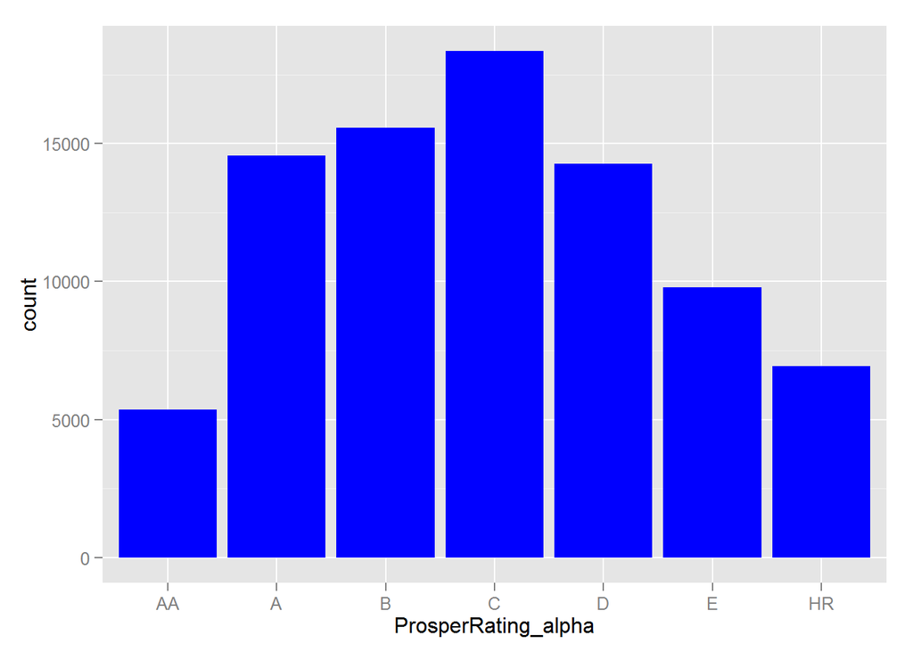

```
##    AA     A     B     C     D     E    HR
##  5372 14551 15581 18345 14274  9795  6935
```

I reordered the ProsperRating_alpha factors, to display them in the sequential order in the charts. Prosper Rating has a normal distribution, with C category having the highest number of loans. Total number of loans for C category are 18345.

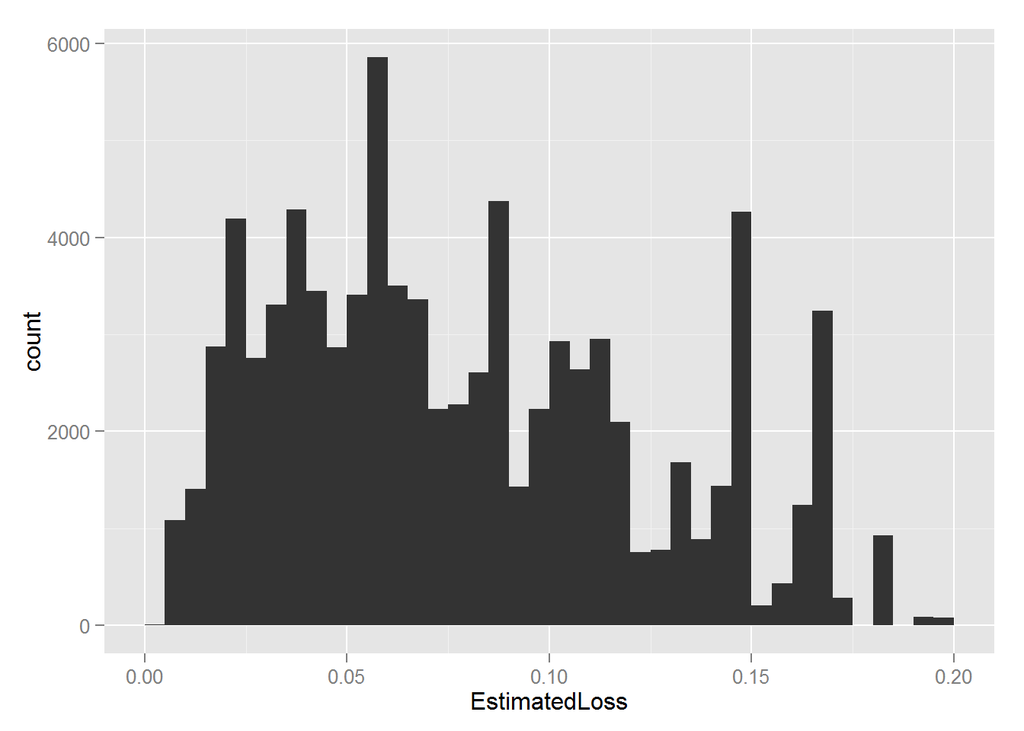

```
##    Min. 1st Qu.  Median    Mean 3rd Qu.    Max.
## 0.00490 0.04240 0.07240 0.08031 0.11200 0.36600
```

We can see that there are few outliers in the chart after 0.2. We can also validate it looking at the statistics. 3rd quartile is at 0.112 and max is at 0.366. I modified the chart to limit the x axis and get a better idea of the distribution. The distribution looks right skewed with few exceptional peaks.

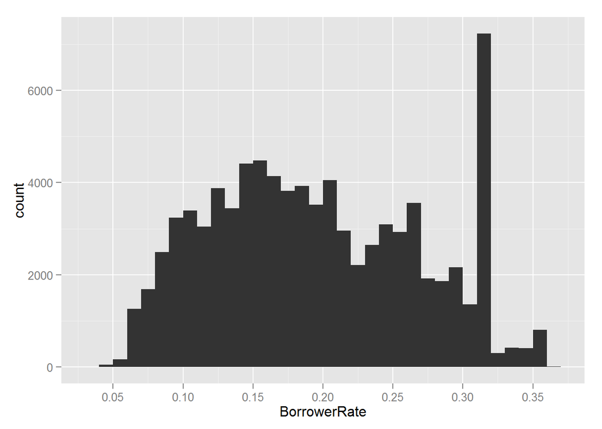

```
##    Min. 1st Qu.  Median    Mean 3rd Qu.    Max.
##  0.0400  0.1359  0.1875  0.1960  0.2574  0.3600
```

The distribution for borrower rate is mostly normal except a peak around 0.31. The mean borrower rate is 0.196 and the minimum is at 0.04.

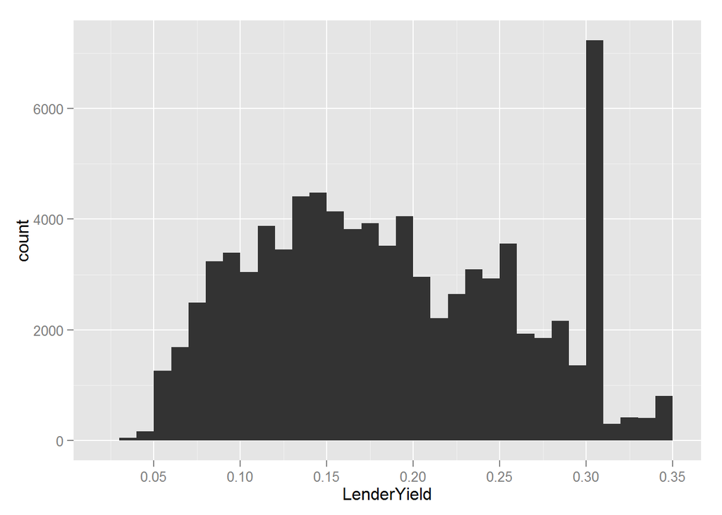

```
##    Min. 1st Qu.  Median    Mean 3rd Qu.    Max.
##  0.0300  0.1259  0.1775  0.1860  0.2474  0.3400
```

### Explore other features of interest like MeanCreditScore, IncomeRange, LoanStatus, and EmploymentStatus.

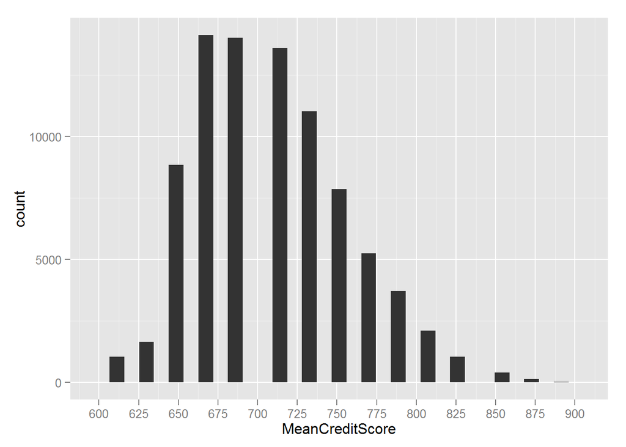

```
##    Min. 1st Qu.  Median    Mean 3rd Qu.    Max.
##   609.5   669.5   709.5   708.9   729.5   889.5
```

The distribution looks a little postively skewed. There is an unusual gap between 685 and 715, and then again between 830 and 850.

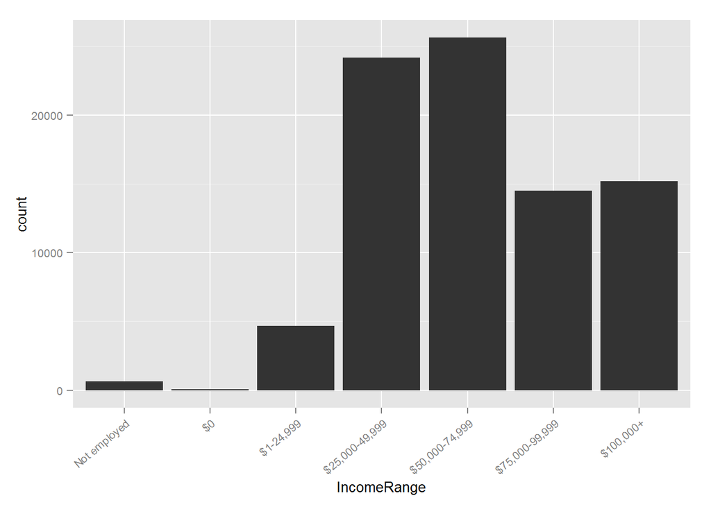

```
##   Not employed             $0      $1-24,999 $25,000-49,999 $50,000-74,999
##            649             45           4654          24175          25627
## $75,000-99,999      $100,000+
##          14498          15205
```

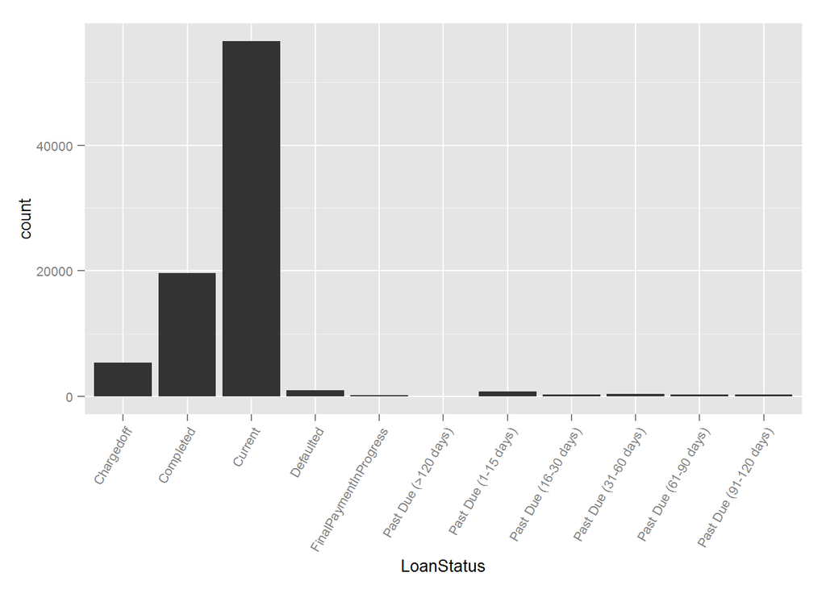

```
##              Cancelled             Chargedoff              Completed
##                      0                   5336                  19664
##                Current              Defaulted FinalPaymentInProgress
##                  56576                   1005                    205
##   Past Due (>120 days)   Past Due (1-15 days)  Past Due (16-30 days)
##                     16                    806                    265
##  Past Due (31-60 days)  Past Due (61-90 days) Past Due (91-120 days)
##                    363                    313                    304
```

Distribution is positively skewed. Most of the loans are either completed(repaid in full) or currently in process of repayment. There are very few loans that are either charged off, defaulted or past due dates. Total loans are 84853, Out of which 19664 loans are completed, 56576 loans are in current status, and 5336 are charged off.

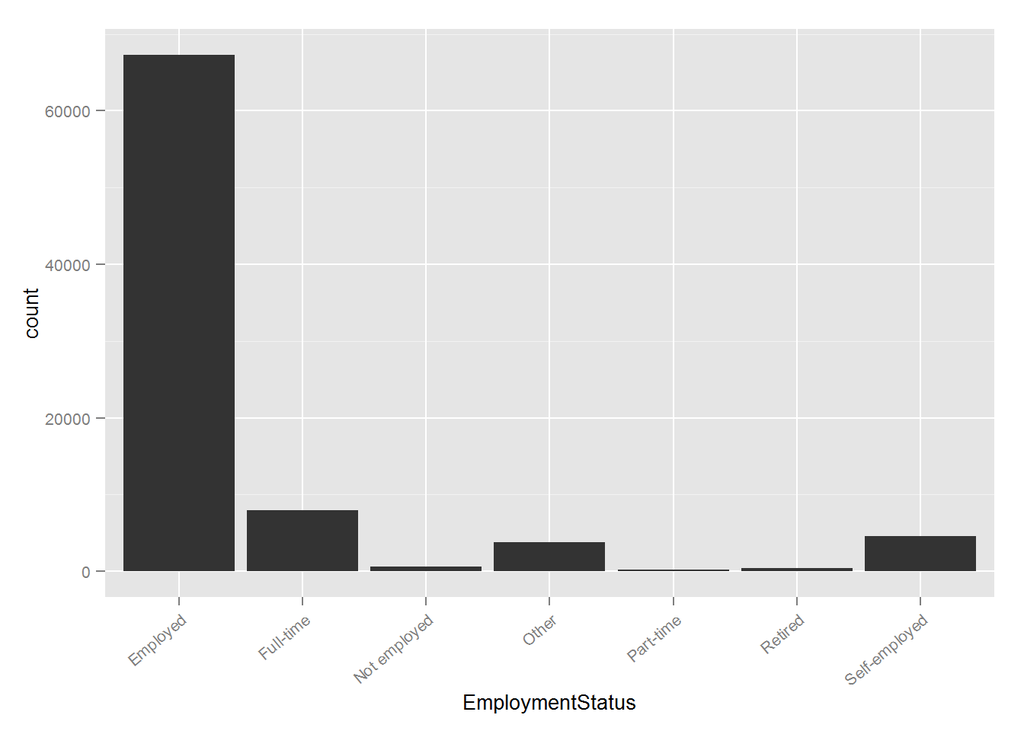

```
##                    Employed     Full-time Not available  Not employed
##             0         67310          7927             0           649
##         Other     Part-time       Retired Self-employed
##          3806           256           367          4538
```

Distribution is positively skewed. Most of the borrowers are employed. Few have categorized themselves as full-time, half-time or self-employed. There are fewer who are not employed or retired. Total borrowers are 84853, out of which 67310 are employed, and only 649 are not employed. There are few more borrowers in other categories. Check the summary.

### Explore few other variables to understand general trends about the data, like number of loans by quarter/year, breakdown by state, etc.

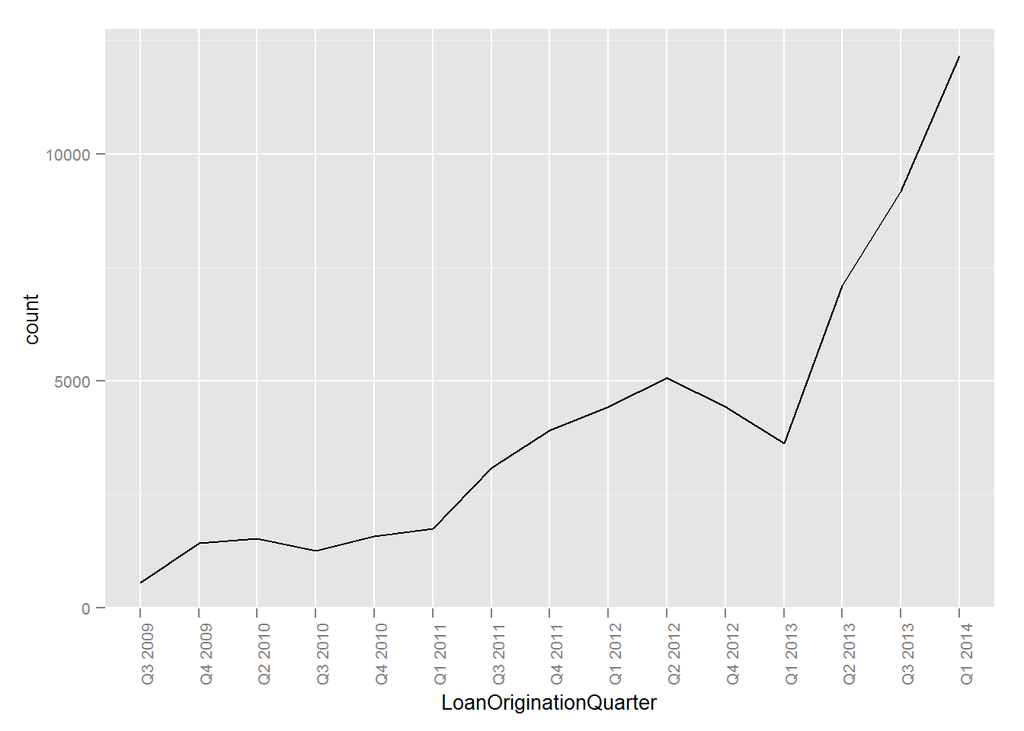

I reordered the LoanOriginationQuarter factors, to display them in the sequential order in the charts. The frequency plot for total number of loans depicts that prosper loans are becoming popular with time. There is a steep rise from Q1 2013 to Q4 2013.

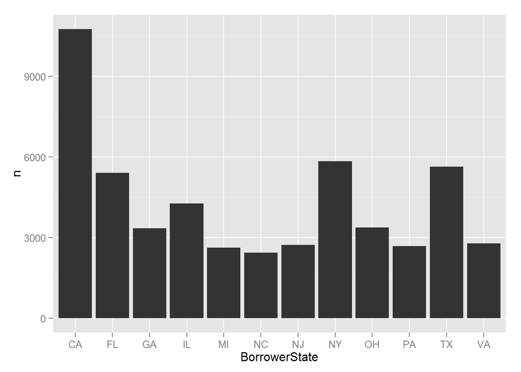

Here I am trying to get the top borrower states constituting of 75% of the total loans. As per my analysis, I have found top 12 borrower states and the histogram depicst the breakdown of number of loans. California is the top borrower state with 10761 loans.

# Univariate Analysis

### What is the structure of your dataset?

Prosper is America’s first peer-to-peer lending marketplace, founded in 2005. Borrower can request personal loans, and propser verifies the borrower’s identity and other related information before granting the loan. Prosper handles the servicing of the loan, collects borrower payments, and distributes interest back to the loan investors.

### What is/are the main feature(s) of interest in your dataset?

The main features are Prosper Rating, Estimated Loss Rate, Borrower Rate, and Lender Yield. From 2006 to 2009, Prosper had a variable rate model. From July 2009, Prosper started assigning Prosper Rating to prospective borrowers. According to the company, Prosper Rating is calculated based on borrower’s estimated loss rate.

### What other features in the dataset do you think will help support your investigation into your feature(s) of interest?

Few other features that will be helpful to support the investigation are DebtToIncomeRatio, Income Range, Employment Status, Loan Status, Loan Original Amount, Investors, etc.

### Did you create any new variables from existing variables in the dataset?

I modified the dataset to only include the records with Prosper Rating, i.e. since July 2009. I also added a new variable MeanCreditScore, calculated from CreditScoreLowerRange and CreditScoreUpperRange, so that I can use it for comparisons and investigation.

### Of the features you investigated, were there any unusual distributions? Did you perform any operations on the data to tidy, adjust, or change the form of the data? If so, why did you do this?

- Distribution for BorrowerRate was mostly normal, except a peak around 0.31
- Distribution for ProsperRating was normal.
- The distribution looks a little postively skewed. There is an unusual gap between 685 and 715, and then again between 830 and 850.
- The frequency plot for total number of loans depicts that prosper loans are becoming popular with time. There is a steep rise from Q1 2013 to Q4 2013.
- I reordered the ProsperRating and LoanOriginationQuarter factors, to display them in the sequential order in the charts.
- I also used the group by and summarise function to find the states with the highest number of loans.

# Bivariate Plots Section

### Explore relationship among main features.

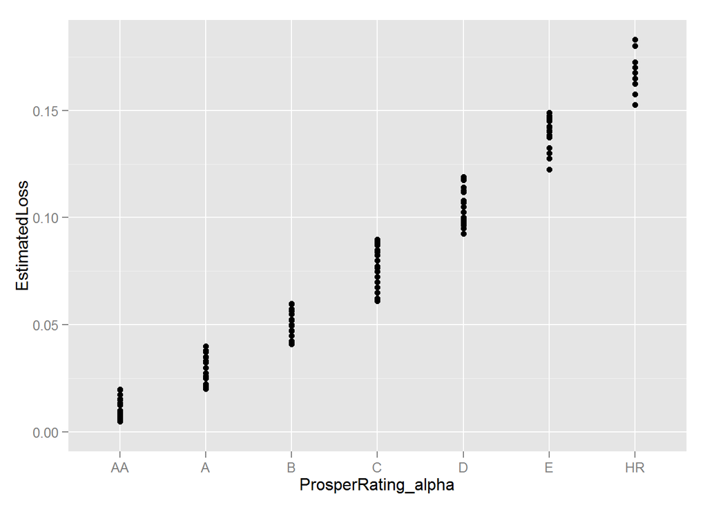

```
##
##  Pearson's product-moment correlation
##
## data:  ProsperRating_numeric and EstimatedLoss
## t = -1058.9, df = 84851, p-value < 2.2e-16
## alternative hypothesis: true correlation is not equal to 0
## 95 percent confidence interval:
##  -0.9646522 -0.9637054
## sample estimates:
##        cor
## -0.9641819
```

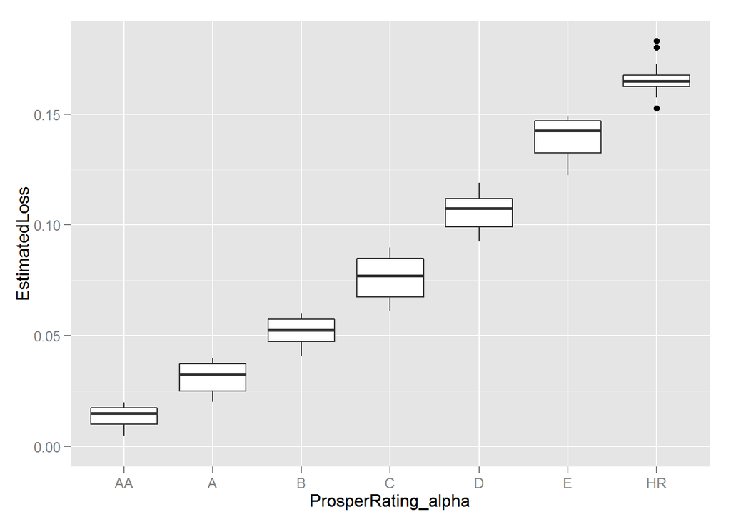

```
## loandata_2009$ProsperRating_alpha: AA
##    Min. 1st Qu.  Median    Mean 3rd Qu.    Max.
## 0.00490 0.01000 0.01500 0.01435 0.01740 0.01990
## --------------------------------------------------------
## loandata_2009$ProsperRating_alpha: A
##    Min. 1st Qu.  Median    Mean 3rd Qu.    Max.
## 0.02000 0.02490 0.03240 0.03072 0.03740 0.03990
## --------------------------------------------------------
## loandata_2009$ProsperRating_alpha: B
##    Min. 1st Qu.  Median    Mean 3rd Qu.    Max.
## 0.04100 0.04740 0.05240 0.05229 0.05740 0.05990
## --------------------------------------------------------
## loandata_2009$ProsperRating_alpha: C
##    Min. 1st Qu.  Median    Mean 3rd Qu.    Max.
## 0.06100 0.06740 0.07700 0.07615 0.08490 0.08990
## --------------------------------------------------------
## loandata_2009$ProsperRating_alpha: D
##    Min. 1st Qu.  Median    Mean 3rd Qu.    Max.
##  0.0925  0.0990  0.1075  0.1058  0.1120  0.1190
## --------------------------------------------------------
## loandata_2009$ProsperRating_alpha: E
##    Min. 1st Qu.  Median    Mean 3rd Qu.    Max.
##  0.1225  0.1325  0.1425  0.1395  0.1470  0.1490
## --------------------------------------------------------
## loandata_2009$ProsperRating_alpha: HR
##    Min. 1st Qu.  Median    Mean 3rd Qu.    Max.
##  0.1525  0.1625  0.1650  0.1733  0.1700  0.3660
```

This chart depicts the relatioship between estimated loss and prosper rating. I can see a strong correlation between estimated loss and prosper rating. To avoid the outliers, I am excluding the top 1% y-values. As calculated by Pearson’s method, correlation is -0.96, with a 95% confidence interval. So, there is a strong negative correlation between both variables. Due to overlapping values, using box plot to better understand the statistics. Also calculated the statistics for each prosper rating. As we can see, median (0.015) for AA is quite close to Max value(0.0199). We can also see the evidence of outliers for HR, with Max being at 0.37 and 3rd quartile at 0.17. Max is way high when compared to 3rd quartile.

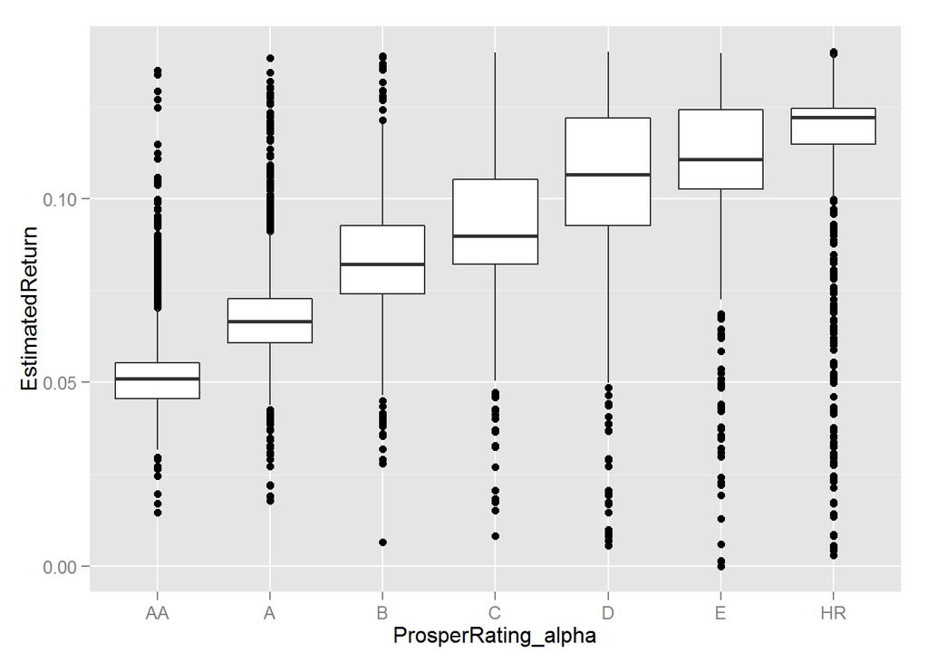

```
##
##  Pearson's product-moment correlation
##
## data:  ProsperRating_numeric and EstimatedReturn
## t = -255.89, df = 84851, p-value < 2.2e-16
## alternative hypothesis: true correlation is not equal to 0
## 95 percent confidence interval:
##  -0.6637612 -0.6561656
## sample estimates:
##        cor
## -0.6599802
```

Due to many overlapping values, I decided to go with the box plot. I can see many outliers even after excluding top 10% values. Unlike Estimated Loss chart, the first quartile for one of the lower prosper rating might be less than the third quartile of the higher propser rating. I don’t see a strong correlation between the two variables. To validate my findings, I calculated correlation by Pearson’s method. correlation is -0.66, 95% confidence interval. So, they are related but do not have a strong relationship.

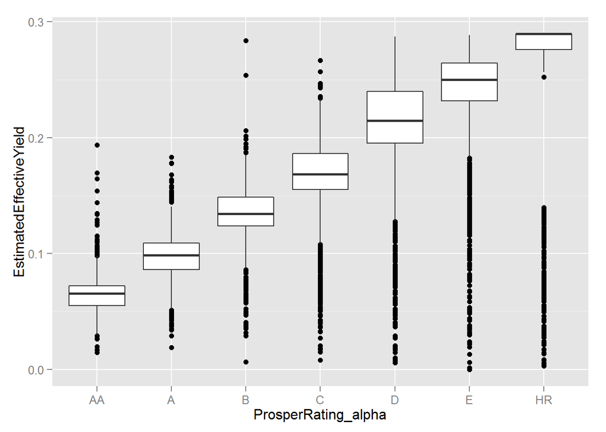

```
##
##  Pearson's product-moment correlation
##
## data:  ProsperRating_numeric and EstimatedEffectiveYield
## t = -466.84, df = 84851, p-value < 2.2e-16
## alternative hypothesis: true correlation is not equal to 0
## 95 percent confidence interval:
##  -0.8502684 -0.8464972
## sample estimates:
##        cor
## -0.8483936
```

```
## loandata_2009$ProsperRating_alpha: AA
##    Min. 1st Qu.  Median    Mean 3rd Qu.    Max.
## 0.01460 0.05519 0.06546 0.06638 0.07230 0.19360
## --------------------------------------------------------
## loandata_2009$ProsperRating_alpha: A
##    Min. 1st Qu.  Median    Mean 3rd Qu.    Max.
## 0.01890 0.08620 0.09860 0.09817 0.10910 0.18310
## --------------------------------------------------------
## loandata_2009$ProsperRating_alpha: B
##    Min. 1st Qu.  Median    Mean 3rd Qu.    Max.
## -0.0010  0.1238  0.1345  0.1365  0.1487  0.2837
## --------------------------------------------------------
## loandata_2009$ProsperRating_alpha: C
##    Min. 1st Qu.  Median    Mean 3rd Qu.    Max.
## -0.0091  0.1551  0.1686  0.1705  0.1864  0.2667
## --------------------------------------------------------
## loandata_2009$ProsperRating_alpha: D
##    Min. 1st Qu.  Median    Mean 3rd Qu.    Max.
## -0.0045  0.1952  0.2148  0.2130  0.2400  0.2875
## --------------------------------------------------------
## loandata_2009$ProsperRating_alpha: E
##    Min. 1st Qu.  Median    Mean 3rd Qu.    Max.
## -0.0124  0.2367  0.2566  0.2524  0.2849  0.3057
## --------------------------------------------------------
## loandata_2009$ProsperRating_alpha: HR
##    Min. 1st Qu.  Median    Mean 3rd Qu.    Max.
## -0.1827  0.2760  0.2896  0.2539  0.2896  0.3199
```

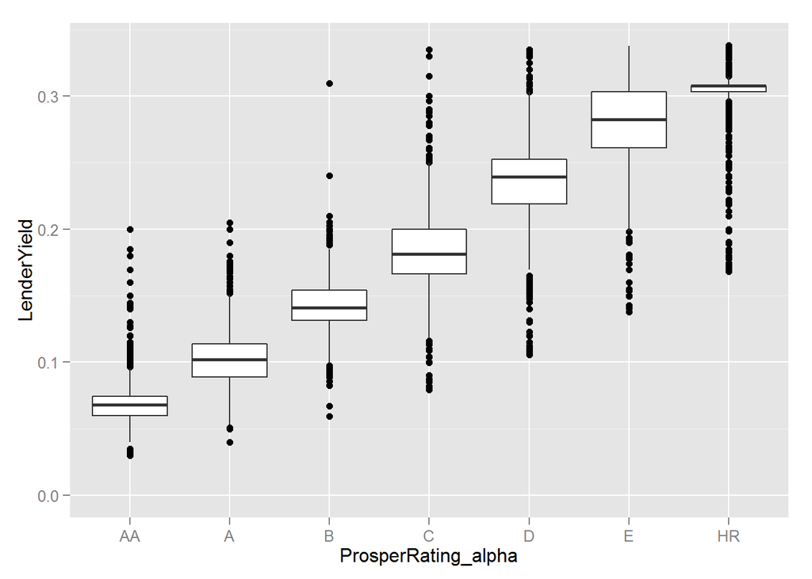

```
##
##  Pearson's product-moment correlation
##
## data:  ProsperRating_numeric and LenderYield
## t = -917.52, df = 84851, p-value < 2.2e-16
## alternative hypothesis: true correlation is not equal to 0
## 95 percent confidence interval:
##  -0.9537315 -0.9524993
## sample estimates:
##        cor
## -0.9531194
```

I can see some outliers. Like Estimated Loss chart, the quartile boundaries are separated for all the propsper rating. I see a strong correlation. To validate my findings, I calculated correlation by Pearson’s method. correlation is -0.95 with 95% confidence interval, implies the relationship as strong as estimated loss.

### Relationship between main features and other features

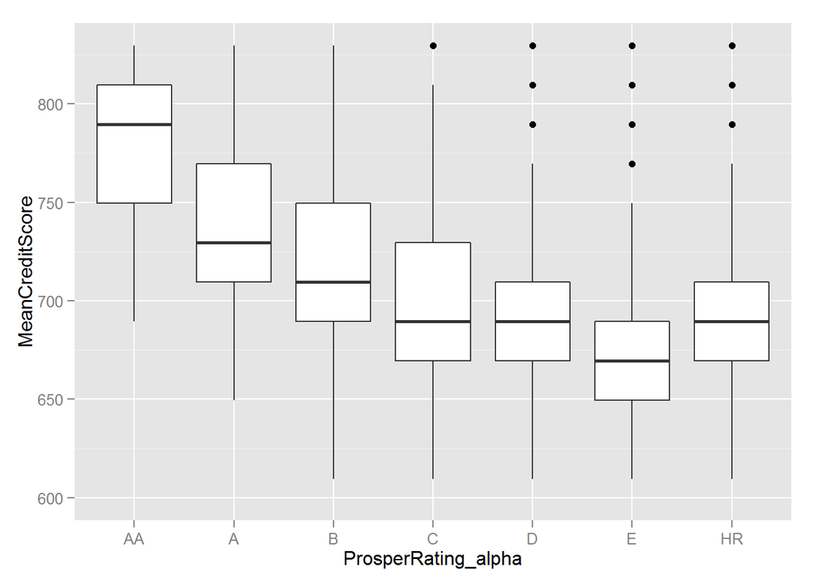

```
##
##  Pearson's product-moment correlation
##
## data:  ProsperRating_numeric and MeanCreditScore
## t = 191.27, df = 84851, p-value < 2.2e-16
## alternative hypothesis: true correlation is not equal to 0
## 95 percent confidence interval:
##  0.544155 0.553558
## sample estimates:
##       cor
## 0.5488738
```

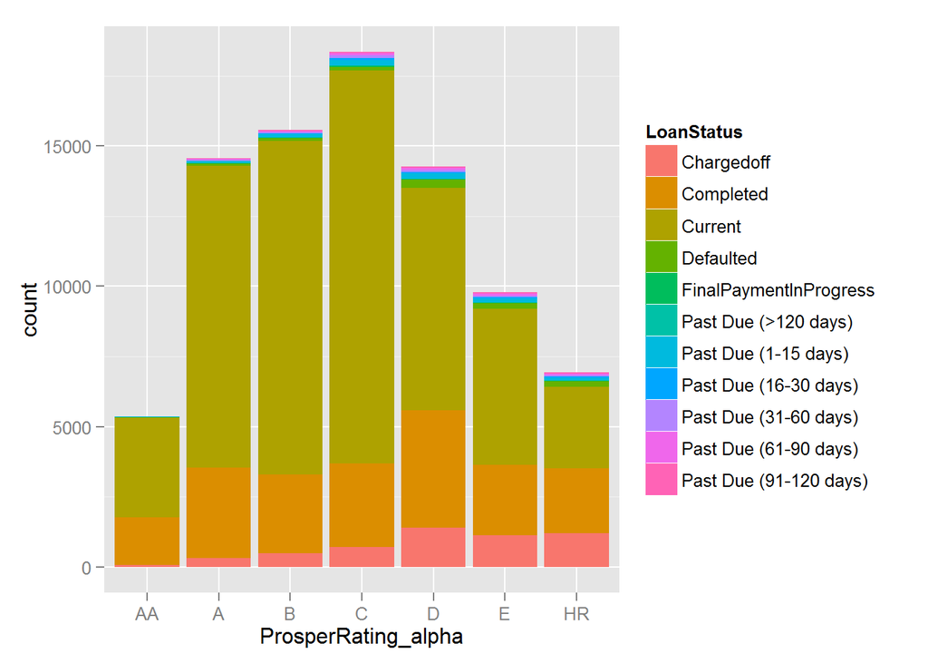

```
## loandata_2009$ProsperRating_alpha: AA
##              Cancelled             Chargedoff              Completed
##                      0                     63                   1700
##                Current              Defaulted FinalPaymentInProgress
##                   3551                     20                     13
##   Past Due (>120 days)   Past Due (1-15 days)  Past Due (16-30 days)
##                      0                      7                      3
##  Past Due (31-60 days)  Past Due (61-90 days) Past Due (91-120 days)
##                      7                      2                      6
## --------------------------------------------------------
## loandata_2009$ProsperRating_alpha: A
##              Cancelled             Chargedoff              Completed
##                      0                    326                   3203
##                Current              Defaulted FinalPaymentInProgress
##                  10755                     79                     34
##   Past Due (>120 days)   Past Due (1-15 days)  Past Due (16-30 days)
##                      0                     62                     14
##  Past Due (31-60 days)  Past Due (61-90 days) Past Due (91-120 days)
##                     29                     24                     25
## --------------------------------------------------------
## loandata_2009$ProsperRating_alpha: B
##              Cancelled             Chargedoff              Completed
##                      0                    500                   2785
##                Current              Defaulted FinalPaymentInProgress
##                  11891                     88                     39
##   Past Due (>120 days)   Past Due (1-15 days)  Past Due (16-30 days)
##                      2                    109                     44
##  Past Due (31-60 days)  Past Due (61-90 days) Past Due (91-120 days)
##                     36                     38                     49
## --------------------------------------------------------
## loandata_2009$ProsperRating_alpha: C
##              Cancelled             Chargedoff              Completed
##                      0                    706                   2977
##                Current              Defaulted FinalPaymentInProgress
##                  14001                    134                     38
##   Past Due (>120 days)   Past Due (1-15 days)  Past Due (16-30 days)
##                      4                    203                     61
##  Past Due (31-60 days)  Past Due (61-90 days) Past Due (91-120 days)
##                     93                     78                     50
## --------------------------------------------------------
```

[output cut: 14 more lines]

```
##                   5558                    193                     32
##   Past Due (>120 days)   Past Due (1-15 days)  Past Due (16-30 days)
##                      4                    136                     50
##  Past Due (31-60 days)  Past Due (61-90 days) Past Due (91-120 days)
##                     67                     55                     63
## --------------------------------------------------------
## loandata_2009$ProsperRating_alpha: HR
##              Cancelled             Chargedoff              Completed
##                      0                   1215                   2301
##                Current              Defaulted FinalPaymentInProgress
##                   2900                    209                     21
##   Past Due (>120 days)   Past Due (1-15 days)  Past Due (16-30 days)
##                      2                     99                     40
##  Past Due (31-60 days)  Past Due (61-90 days) Past Due (91-120 days)
##                     47                     58                     43
```

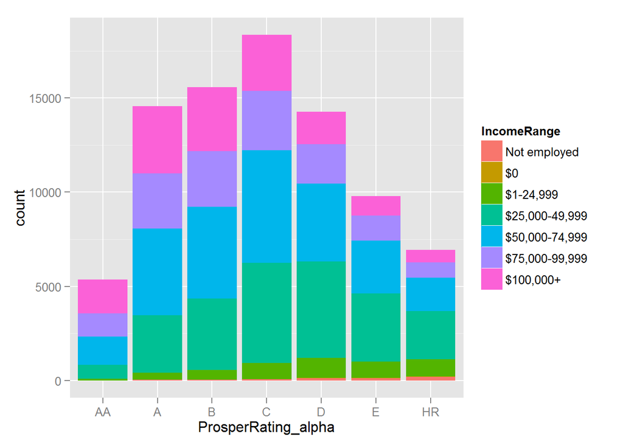

```
## loandata_2009$ProsperRating_alpha: AA
##   Not employed             $0      $1-24,999 $25,000-49,999 $50,000-74,999
##              5              0             88            736           1497
## $75,000-99,999      $100,000+
##           1227           1819
## --------------------------------------------------------
## loandata_2009$ProsperRating_alpha: A
##   Not employed             $0      $1-24,999 $25,000-49,999 $50,000-74,999
##             46              2            378           3031           4609
## $75,000-99,999      $100,000+
##           2930           3555
## --------------------------------------------------------
## loandata_2009$ProsperRating_alpha: B
##   Not employed             $0      $1-24,999 $25,000-49,999 $50,000-74,999
##             53              3            517           3780           4861
## $75,000-99,999      $100,000+
##           2957           3410
## --------------------------------------------------------
## loandata_2009$ProsperRating_alpha: C
##   Not employed             $0      $1-24,999 $25,000-49,999 $50,000-74,999
##             82              2            839           5332           5970
## $75,000-99,999      $100,000+
##           3139           2981
## --------------------------------------------------------
## loandata_2009$ProsperRating_alpha: D
##   Not employed             $0      $1-24,999 $25,000-49,999 $50,000-74,999
##            132             15           1049           5114           4133
## $75,000-99,999      $100,000+
##           2096           1735
## --------------------------------------------------------
## loandata_2009$ProsperRating_alpha: E
##   Not employed             $0      $1-24,999 $25,000-49,999 $50,000-74,999
##            130              6            871           3622           2793
## $75,000-99,999      $100,000+
##           1329           1044
## --------------------------------------------------------
## loandata_2009$ProsperRating_alpha: HR
##   Not employed             $0      $1-24,999 $25,000-49,999 $50,000-74,999
##            201             17            912           2560           1764
## $75,000-99,999      $100,000+
##            820            661
```

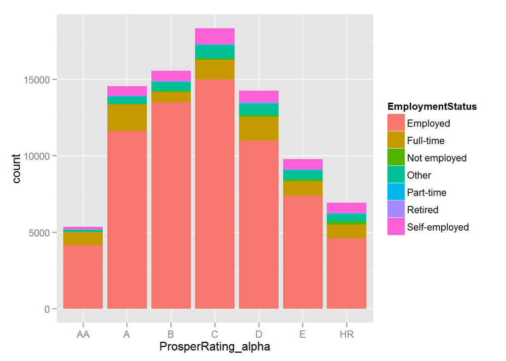

```
## loandata_2009$ProsperRating_alpha: AA
##                    Employed     Full-time Not available  Not employed
##             0          4157           866             0             5
##         Other     Part-time       Retired Self-employed
##           126            16            29           173
## --------------------------------------------------------
## loandata_2009$ProsperRating_alpha: A
##                    Employed     Full-time Not available  Not employed
##             0         11629          1739             0            46
##         Other     Part-time       Retired Self-employed
##           425            55            56           601
## --------------------------------------------------------
## loandata_2009$ProsperRating_alpha: B
##                    Employed     Full-time Not available  Not employed
##             0         13507           681             0            53
##         Other     Part-time       Retired Self-employed
##           600            22            39           679
## --------------------------------------------------------
## loandata_2009$ProsperRating_alpha: C
##                    Employed     Full-time Not available  Not employed
##             0         15002          1289             0            82
##         Other     Part-time       Retired Self-employed
##           868            30            54          1020
## --------------------------------------------------------
## loandata_2009$ProsperRating_alpha: D
##                    Employed     Full-time Not available  Not employed
##             0         11004          1533             0           132
##         Other     Part-time       Retired Self-employed
##           714            55            86           750
## --------------------------------------------------------
## loandata_2009$ProsperRating_alpha: E
##                    Employed     Full-time Not available  Not employed
##             0          7402           926             0           130
##         Other     Part-time       Retired Self-employed
##           582            46            50           659
## --------------------------------------------------------
## loandata_2009$ProsperRating_alpha: HR
##                    Employed     Full-time Not available  Not employed
##             0          4609           893             0           201
##         Other     Part-time       Retired Self-employed
##           491            32            53           656
```

Depicts the breakdown of each prosper rating by employment status. Breakdown looks similar for almost all the prosper ratings. On looking at the statistics, we can see that breakdown is similar for all prosper rating. Employed borrowers have way more number of loans, as compared to non-employed borrowers. Please check the summary.

### Explore relationship between other variables

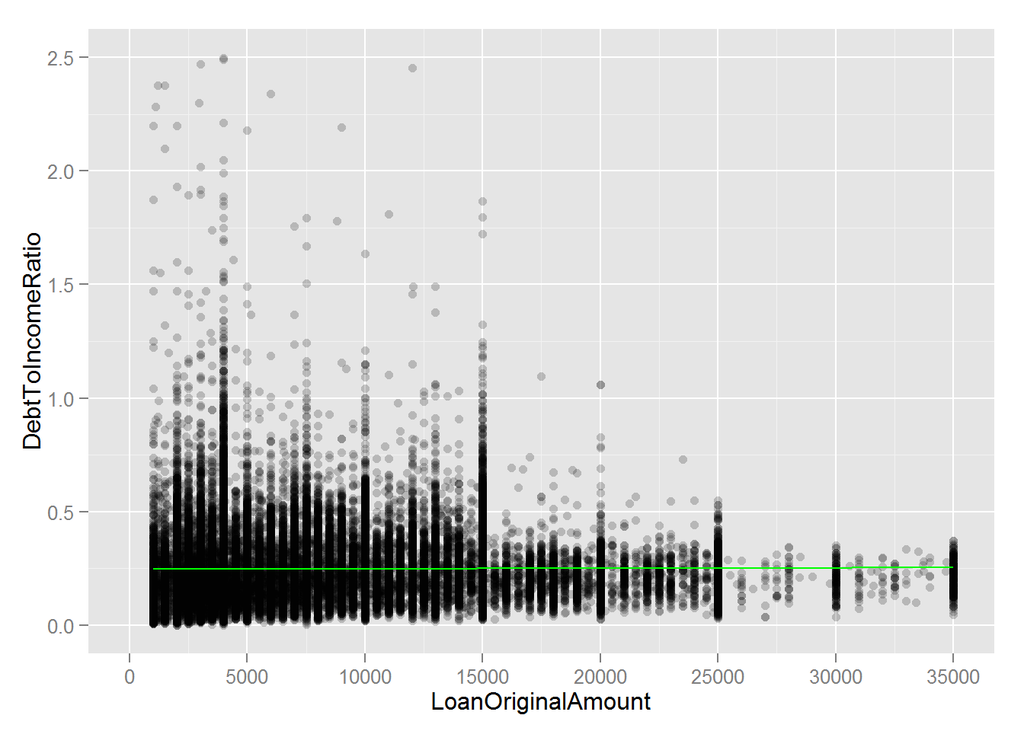

```
##
##  Pearson's product-moment correlation
##
## data:  LoanOriginalAmount and DebtToIncomeRatio
## t = -4.9683, df = 77555, p-value = 6.769e-07
## alternative hypothesis: true correlation is not equal to 0
## 95 percent confidence interval:
##  -0.02487217 -0.01080098
## sample estimates:
##         cor
## -0.01783746
```

```
##        (Intercept) LoanOriginalAmount
##       2.669778e-01      -8.874328e-07
```

# Bivariate Analysis

### Talk about some of the relationships you observed in this part of the investigation. How did the feature(s) of interest vary with other features in the dataset?

- Here I have explored the relationship of ProsperRating with EstimatedLoss, EstimatedReturn, EstimatedEffectiveYield, and LenderYield. I can see the strongest correlation between prosper rating, estimated loss and lender yield. There is a strong relationship between prosper rating and estimated effective yield. but it is not as strong for estimated return.
- I also investigated the relationship of prosper rating with other categorical features (Loan Status, Income Range, and Employment Status). The breakdown for categorical features looks similar for Loan Status and Employment Status. However, there is a trend for Income Range as explained in the chart.

### Did you observe any interesting relationships between the other features (not the main feature(s) of interest)?

- Yes, I investiagted if there is a relationship between LoanOriginalAmount and DebtToIncomeRatio. But, as explained above in the chart, I was not able to find any relationship between two variables.

### What was the strongest relationship you found?

The strongest relationship was found between ProsperRating and EstimatedLoss. It has a negative correlation of -0.96. As the estimated loss increases, prosper rating becomes worse.

# Multivariate Plots Section

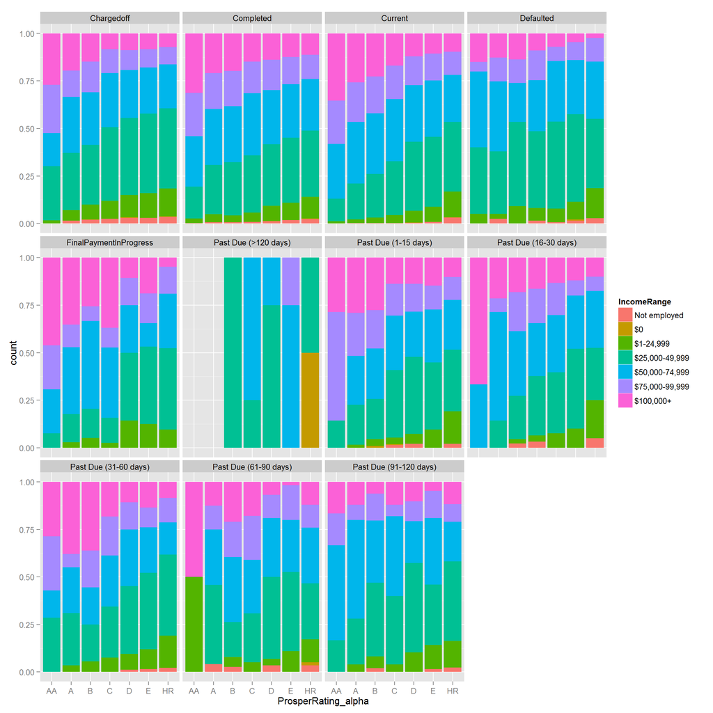

This charge depicts the relationship between income range and prosper rating, by loan status. As concluded in above sections, completed, current, charged off, and defaulted holds the most number of loans. These loan statuses have similar distribution of income range, with the highest income range decreasing from AA to HR. However, there are few variations in the pattern for other statuses, the most peculiar being for Past Due (>120 days).There are no highest income range ($100,000+) borrowers or top two prosper rating (AA, A) borrowers with the loan status past dues (>120 days).

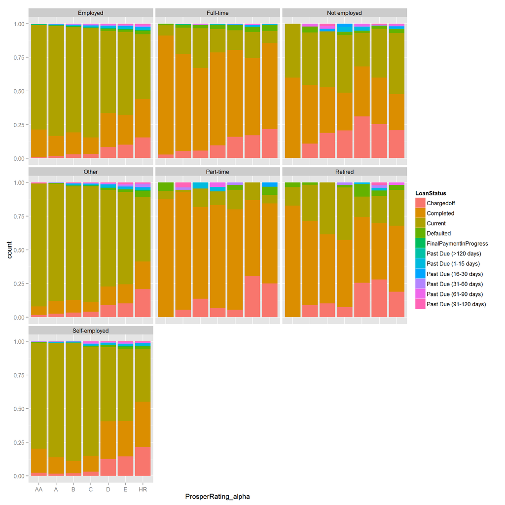

This chart depicts the relationship between loan status and prosper rating, by employment status. For each employment status, we can see the breakdown of loan status over propsper rating. The number of completed loans are more than the current loans for part-time, retired, and full-time employee. However, for employed, self-employed, and other, current are more than the completed. Also, current and completed statuses holds a major percentage of total loans.

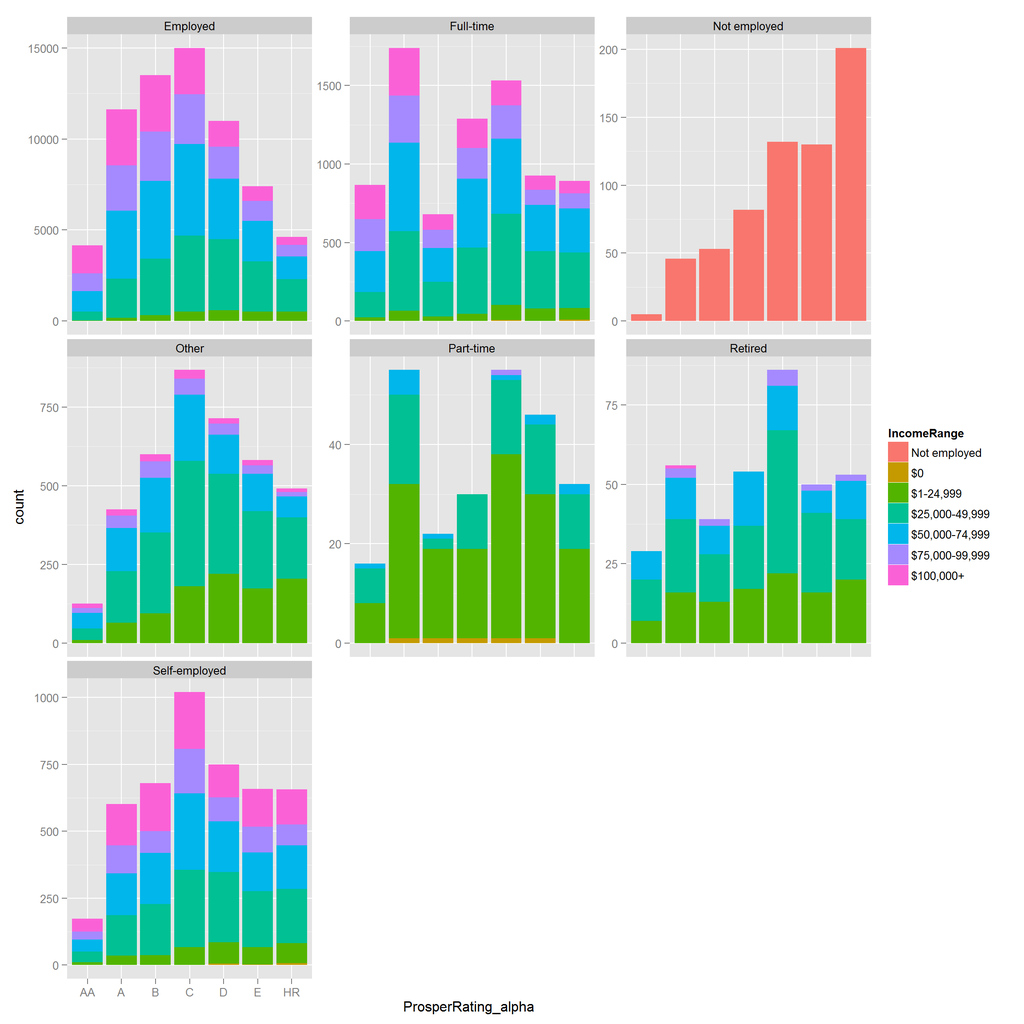

This chart depicts the relationship between income range and prosper rating, by employment status. For each employment status, we can see the breakdown of income range by prosper rating. Most of the part-time and retired borrowers have an income range of 74,999 or less and very few to none with an income of 75,000 or more. We can also see that only for not employed, number of borrowers with HR rating is more than any other ratings. Full-time employees have more borrowers with A rating.

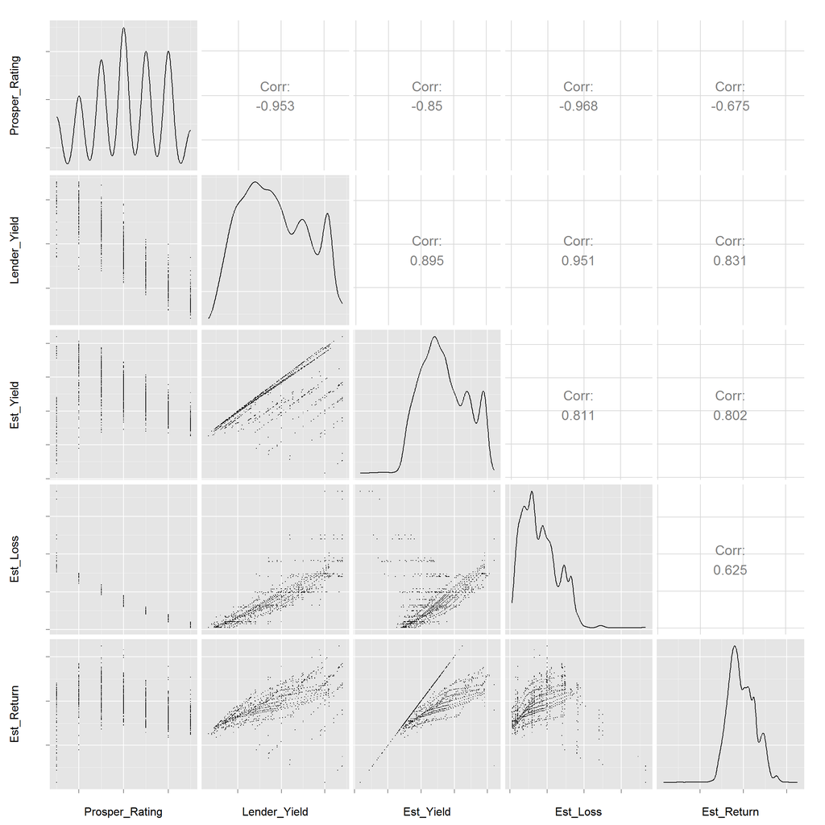

I am using scatterplot matrices to display the pairwise relationship between my main features. We can see that all the main features are highly correlated to each other, except estimated return.

# Multivariate Analysis

### Talk about some of the relationships you observed in this part of the investigation. Were there features that strengthened each other in terms of looking at your feature(s) of interest?

- Plotted prosper rating in combination of categorical variables to identify the trends. I don’t see that other features strengthen each other in terms of prosper rating. However, I did identified few trends explained below each chart.
- All the main features are highly correlated to each other, except estimated return.

### Were there any interesting or surprising interactions between features?

# Final Plots and Summary

### Plot One

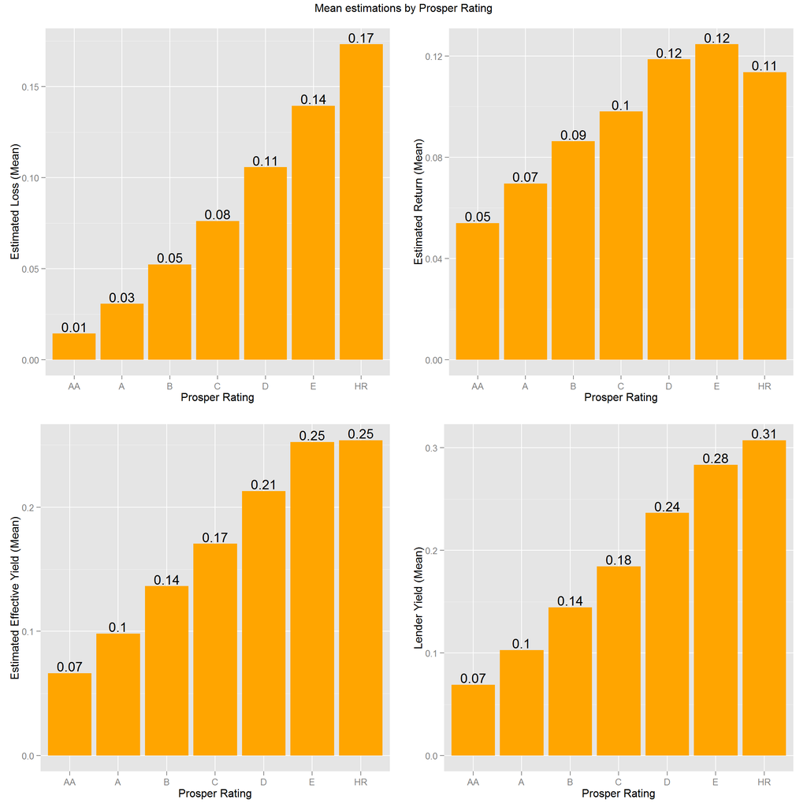

### Description One

As a lender/investor coming to the prosper marketplace, I would like to know few basic insights to make informed decisions.

This visualization will help the lender to get a quick view of the loss/profit rates for each prosper rating, and this will help the lender to make informed decisions on how to invest his money. The genreral trend is that high estimated loss are marked as high risk. In return, high risk loans have high estimated returns and high yield. However, there is an exception where Prosper rating E has comparatively less loss rate than HR, but high return rate.

### Plot Two

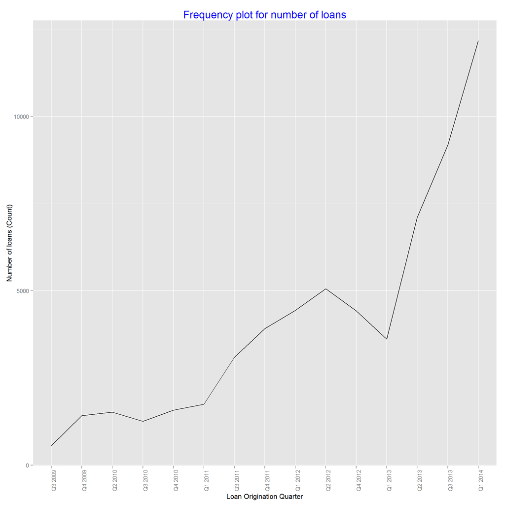

```
## Source: local data frame [16 x 2]
##
##    LoanOriginationQuarter     n
##                    (fctr) (int)
## 1                 Q3 2009   559
## 2                 Q4 2009  1417
## 3                 Q2 2010  1518
## 4                 Q3 2010  1256
## 5                 Q4 2010  1579
## 6                 Q1 2011  1744
## 7                 Q3 2011  3093
## 8                 Q4 2011  3913
## 9                 Q1 2012  4435
## 10                Q2 2012  5061
## 11                Q4 2012  4425
## 12                Q1 2013  3616
## 13                Q2 2013  7099
## 14                Q3 2013  9180
## 15                Q1 2014 12172
## 16                     NA 23786
```

### Description Two

As a lender/investor, I would like to know the frequency of prosper loans. How popular are prosper loans? Is it trending with time or not?

### Plot Three

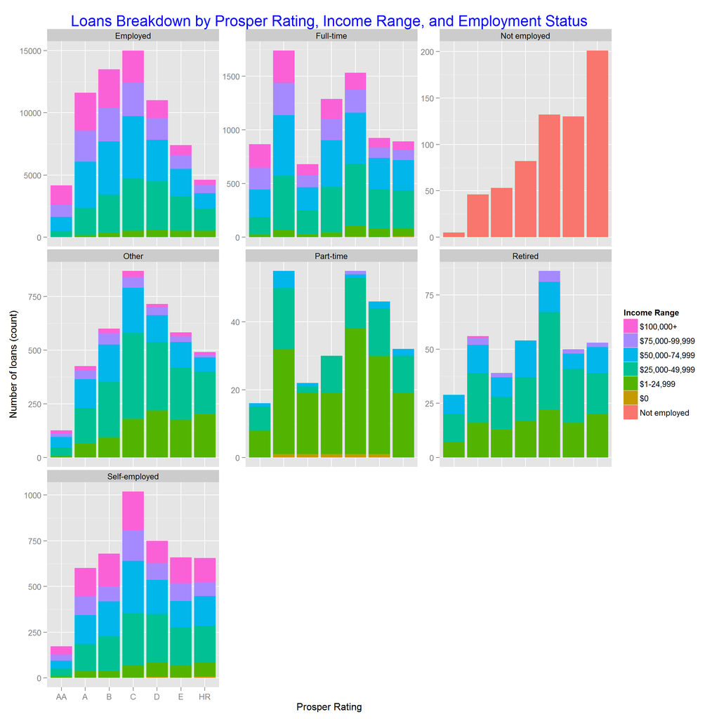

### Description Three

As a lender/investor, I would like to view the historical data for the loans by employment status and income range.

# Reflection

### Where did I run into difficulties in the analysis? Where did I find my successes?

It took me a while to understand the data. At the beginning, I wans’t sure what am I looking at, what are the key features, and what does each variable means. To better understand the data, I reasearched on internet and read the wiki for prosper loans. I also found the variable definition document for prosper loan dataset, shared by Chris on google drive. The context helped me understand the theoretical relationship between the variables and set the questions for my analysis work.

I was trying to find some relationship or pattern between prosper rating and categorical variables like income range, employment status. But, I did not find any useful relationship that I could use to predict the prosper rating for new loan listings. However, I did find the strongest relationship between prosper rating and estimated loss rate. Then again, I think estimated loss is predicted by prosper marketplace as well, and it needs further investigation to build a predicted model based on the information provided by the borrower.

### How could the analysis be enriched in future work (e.g. additional data and analyses)?

As mentioned above, further exploration is required to develop a model to predict the prosper rating based on the information provided by the borrower at the time of loan listing. Also, I do not completely understand all the 81 variables in the dataset, therefore a little more effort is required to study and investigate other variables.